# TestDataAnalysis

```python
import requests
import pandas as pd
import numpy as np
from pandas.io.json import json_normalize
import datetime
import matplotlib.pyplot as plt
import matplotlib.dates as dates

from sklearn.metrics import r2_score

import seaborn as sns
import matplotlib.style as style; style.use('fivethirtyeight')
```

get the data from covid19india.org and create a dataframe df_test using that

```python
url = 'https://api.covid19india.org/state_test_data.json'
r1 = requests.get(url)
dictr1 = r1.json()
```

```python
df_test = pd.DataFrame(dictr1['states_tested_data'])
```

```python
df_test
```

|  | coronaenquirycalls | cumulativepeopleinquarantine | negative | numcallsstatehelpline | numicubeds | numisolationbeds | numventilators | peopleinicu | peopleonventilators | populationncp2019projection | ... | testsperpositivecase | testsperthousand | totaln95masks | totalpeoplecurrentlyinquarantine | totalpeoplereleasedfromquarantine | totalppe | totaltested | unconfirmed | updatedon | _d6ua4 |
| --- | --- | --- | --- | --- | --- | --- | --- | --- | --- | --- | --- | --- | --- | --- | --- | --- | --- | --- | --- | --- | --- |
| 0 |  |  | 1210 |  |  | 50 |  |  |  | 397000 | ... | 117 | 3.53 |  |  |  |  | 1403 | 181 | 17/04/2020 | NaN |
| 1 |  |  |  | 280 |  | 50 |  |  |  | 397000 | ... | 99 | 6.75 |  | 614 | 347 |  | 2679 | 246 | 24/04/2020 | NaN |
| 2 |  |  |  | 298 |  | 50 |  |  |  | 397000 | ... | 86 | 7.17 |  | 724 | 420 |  | 2848 | 106 | 27/04/2020 | NaN |
| 3 |  |  |  | 340 |  | 50 |  |  |  | 397000 | ... | 114 | 9.46 |  | 643 | 556 |  | 3754 | 199 | 01/05/2020 | NaN |
| 4 |  |  |  | 471 |  | 98 |  |  |  | 397000 | ... | 202 | 16.82 |  | 16 | 1196 |  | 6677 | 136 | 16/05/2020 | NaN |
| ... | ... | ... | ... | ... | ... | ... | ... | ... | ... | ... | ... | ... | ... | ... | ... | ... | ... | ... | ... | ... | ... |
| 2675 |  |  |  |  | 948 |  | 395 |  |  | 96906000 | ... | 27 | 4.84 | 976040 | 6937 | 95383 | 1606262 | 468906 |  | 28/06/2020 | NaN |
| 2676 |  |  |  |  | 948 |  | 395 |  |  | 96906000 | ... | 27 | 4.94 | 983040 | 6931 | 95944 | 1618262 | 478419 |  | 29/06/2020 | NaN |
| 2677 |  |  |  |  | 948 |  | 395 |  |  | 96906000 | ... | 26 | 5.04 | 991040 | 6795 | 96162 | 1628262 | 488038 |  | 30/06/2020 | NaN |
| 2678 |  |  |  |  | 948 |  | 395 |  |  | 96906000 | ... | 26 | 5.13 | 1001040 | 6668 | 96702 | 1638262 | 497596 |  | 01/07/2020 | NaN |
| 2679 |  |  |  |  | 948 |  | 395 |  |  | 96906000 | ... | 26 | 5.24 | 1009040 | 6449 | 97290 | 1648262 | 508001 |  | 02/07/2020 | NaN |

2680 rows × 28 columns

Format the dates in datetime format for operations on them

```python
df_test['updatedon'] = df_test['updatedon'].apply(lambda x: datetime.datetime.strptime(x, "%d/%m/%Y").strftime("%Y-%m-%d") if x!='' else x)
df_test['updatedon'] = pd.to_datetime(df_test['updatedon'])
```

Remove % from test positivity rate for conversion into numeric

```python
df_test['testpositivityrate'] = df_test['testpositivityrate'].str.replace('%', '')
```

Convert test positivity rate, total tested, tests per million, tests per positive case, tests per thousand to numeric for arithmetic operations

```python
df_test['testpositivityrate'] = pd.to_numeric(df_test['testpositivityrate'])
df_test['totaltested'] = pd.to_numeric(df_test['totaltested'])
df_test['testspermillion'] = pd.to_numeric(df_test['testspermillion'])
df_test['testsperpositivecase'] = pd.to_numeric(df_test['testsperpositivecase'])
df_test['testsperthousand'] = pd.to_numeric(df_test['testsperthousand'])
```

Create a new dataframe df_test_recent which contains data for last 10 days

```python
df_test_recent = df_test[df_test['updatedon']>=(datetime.datetime.today() - datetime.timedelta(days = 10))]
```

Find average test positivity rate for each state in last 10 days

```python
df_test_recent.groupby('state')['testpositivityrate'].mean()
```

```
state
Andaman and Nicobar Islands                  0.505714
Andhra Pradesh                               1.525000
Arunachal Pradesh                            0.786250
Assam                                        1.890000
Bihar                                        4.490000
Chandigarh                                   5.831250
Chhattisgarh                                 1.755000
Dadra and Nagar Haveli and Daman and Diu     0.590000
Delhi                                       16.635000
Goa                                          1.848750
Gujarat                                      8.643750
Haryana                                      5.398750
Himachal Pradesh                             1.195000
Jammu and Kashmir                            2.015000
Jharkhand                                    1.728750
Karnataka                                    2.176250
Kerala                                       1.881250
Ladakh                                       6.978333
Madhya Pradesh                               3.831250
Maharashtra                                 18.152222
Manipur                                      2.338000
Meghalaya                                    0.268750
Mizoram                                      1.188750
Nagaland                                     2.806250
Odisha                                       2.572500
Puducherry                                   4.012500
Punjab                                       1.802500
Rajasthan                                    2.167500
Sikkim                                       0.841250
Tamil Nadu                                   7.357500
Telangana                                   17.202500
Tripura                                      2.180000
Uttar Pradesh                                3.233750
Uttarakhand                                  4.291250
West Bengal                                  3.703333
Name: testpositivityrate, dtype: float64
```

Find top 5 states which has highest positivity rate in last 10 days

```python
top_5_pr = df_test_recent.groupby('state')['testpositivityrate'].mean().sort_values(ascending=False)[:5]
top_5_pr
```

```
state
Maharashtra    18.152222
Telangana      17.202500
Delhi          16.635000
Gujarat         8.643750
Tamil Nadu      7.357500
Name: testpositivityrate, dtype: float64
```

Plot date vs test positivity rate for top 5 states with highest average test positivity rate in last 10 days

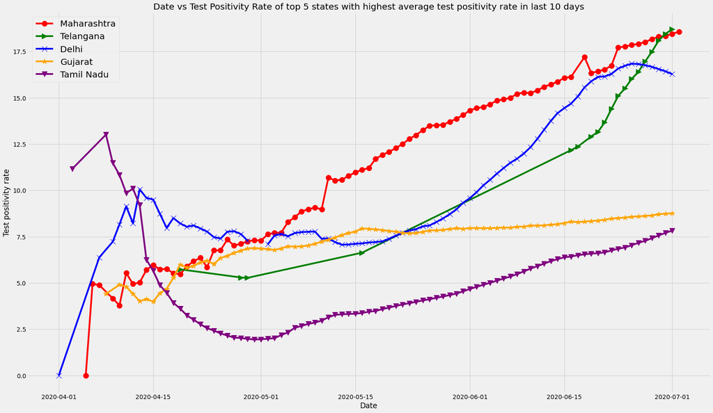

```python
plt.figure(figsize= (25,15))
c=['red','green','blue','orange','purple']
m=["o",">","x","*","v"]
states=top_5_pr.index

for (state,colr,markr) in zip(states,c,m):
    plt.plot(df_test[df_test['state']==state]['updatedon'], df_test[df_test['state']==state]['testpositivityrate'],marker=markr,color=colr,markersize=12,label=state)


plt.title("Date vs Test Positivity Rate of top 5 states with highest average test positivity rate in last 10 days")
plt.ylabel("Test positivity rate")
plt.xlabel("Date")
plt.legend(fontsize ='x-large')
plt.show()
```

Create a new dataframe df_total_tests which has state and total samples tested in last 10 days

```python
recent_total_tests_dict = {'recent_total_tests_data':[]}
for name,group in df_test_recent.groupby('state'):
    recent_total_tests_dict['recent_total_tests_data'].append({
        'state': name,
        'sampletested': group.iloc[len(group)-1]['totaltested'] - group.iloc[0]['totaltested']
    })
```

```python
df_total_tests = pd.DataFrame(recent_total_tests_dict['recent_total_tests_data'])
```

Find top 5 states which did highest number of tests in last 10 days

```python
df_total_tests.iloc[df_total_tests['sampletested'].sort_values(ascending=False)[:5].index]
```

|  | state | sampletested |
| --- | --- | --- |
| 29 | Tamil Nadu | 259261.0 |
| 19 | Maharashtra | 197157.0 |
| 1 | Andhra Pradesh | 182479.0 |
| 32 | Uttar Pradesh | 178194.0 |
| 8 | Delhi | 151823.0 |

Plot bar graph denoting total samples tested by each state

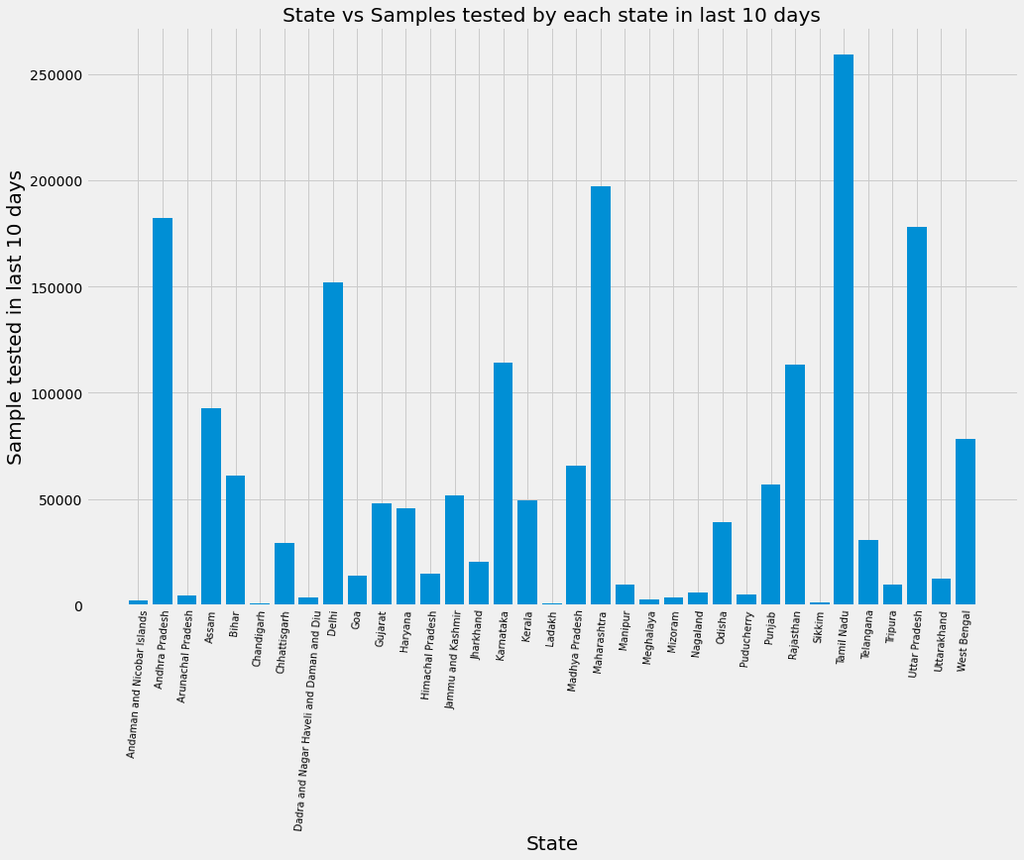

```python
def plot_state_vs_sample_tested():
    label = df_total_tests['state']
    index = np.arange(len(label))
    plt.figure(figsize=(15,10))
    plt.bar(index, df_total_tests['sampletested'])
    plt.xlabel('State', fontsize=20)
    plt.ylabel('Sample tested in last 10 days', fontsize=20)
    plt.xticks(index, label, fontsize=5, rotation=85, size=10)
    plt.title('State vs Samples tested by each state in last 10 days')
    plt.show()
plot_state_vs_sample_tested()
```

Find which states are doing highest tests per thousand? Create a dataframe tpc having state and average tests per thousands for that state

```python
tpc = df_test_recent.groupby('state')['testsperthousand'].mean().sort_values(ascending=False)
```

Top 6 states which did highest average tests per thousand in last 10 days

```python
tpc[:6]
```

```
state
Ladakh                                      46.730000
Goa                                         40.517500
Andaman and Nicobar Islands                 37.394286
Dadra and Nagar Haveli and Daman and Diu    32.402500
Jammu and Kashmir                           26.416250
Delhi                                       24.556250
Name: testsperthousand, dtype: float64
```

Last 6 states which did lowest average tests per thousand in last 10 days

```python
tpc[-6:]
```

```
state
West Bengal       4.834444
Madhya Pradesh    4.162500
Jharkhand         3.655000
Uttar Pradesh     3.005000
Telangana         2.156250
Bihar             1.718889
Name: testsperthousand, dtype: float64
```

Plot date vs tests per thousand for top 6 states with lowest average tests per thousands in last 10 days

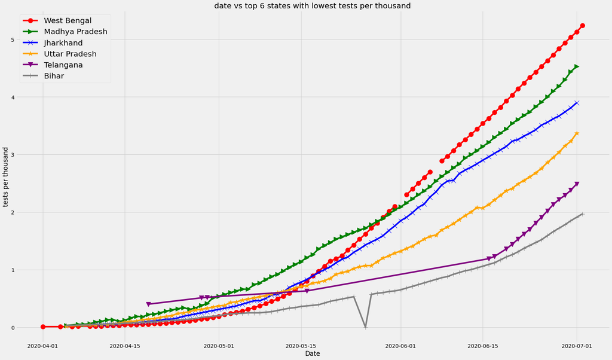

```python
plt.figure(figsize= (25,15))
c=['red','green','blue','orange','purple',"grey"]
m=["o",">","x","*","v","+"]
states=tpc[-6:].index

for (state,colr,markr) in zip(states,c,m):
    plt.plot(df_test[df_test['state']==state]['updatedon'], df_test[df_test['state']==state]['testsperthousand'],marker=markr,color=colr,markersize=12,label=state)


plt.title("date vs top 6 states with lowest tests per thousand")
plt.ylabel("tests per thousand")
plt.xlabel("Date")
plt.legend(fontsize ='x-large')
plt.show()
```